# Community Analgesic Prescribing in Scotland Before, During and After the COVID-19 Pandemic

2025/11/27

# Introduction

The COVID-19 pandemic provides a natural experiment for assessing how a major health-system disruption affected community analgesic prescribing in Scotland. Scotland’s first confirmed COVID-19 case on 1 March 2020 was followed by a national lockdown on 24 March 2020, with rapid expansion of remote consultations and postponement of elective care, and legal restrictions were largely removed by 18 April 2022 (Scottish COVID-19 Inquiry, 2025). COVID-19 also changed the population’s symptom burden. Headache, dyspnoea, myalgia, musculoskeletal pain and persistent cough were common features of both acute infection and post-viral illness (Evcik, 2023; Nalbandian et al., 2021). As a result, analgesics, from first-line agents such as paracetamol to stronger options such as co-codamol were frequently used to manage moderate to severe symptoms. These clinical patterns provide context for interpreting prescribing changes across the pandemic. Using Public Health Scotland “Prescriptions in the Community” data, this analysis examines how analgesic prescribing evolved across three non-overlapping 26-month windows:

- Before COVID: January 2018 – February 2020
- During COVID: March 2020 – April 2022
- After COVID: May 2022 – June 2024

The primary outcome is the number of paid items for analgesics (BNF section 04.07), providing a consistent indicator of prescribing volume over time (Open Prescribing, 2025; Public Health Scotland, 2025). The analysis addresses three questions:

1. Did the overall analgesic prescribing volume change across the three periods?
2. Which specific analgesic products dominated prescribing before, during and after COVID-19, and how did their shares change?
3. Were any observed changes brief responses around the onset of the pandemic, or did they develop into longer-term shifts in practice?

To answer these questions, the report summarises the top-10 most prescribed analgesics by volume in each period, analyses changes in their percentage share using a heatmap, and evaluates monthly time-series for both total analgesic items and the union of top-10 analgesics.

# Data Loading

```r
## Purpose: Load core packages for data wrangling, tables, paths, and plotting
library(tidyverse)
library(janitor) # cleaning data
library(gt) # nicely formatted tables
library(here) # directory structure
library(scales) # number/percent formatting
library(glue) # string interpolation for labels
```

```r
## Purpose: Import data from before, during, and after COVID-19, keeping only BNF code, BNF item drscription, and number of paid items
read_cols <- function(path){read_csv(path) %>%
    clean_names() %>%
    select(any_of(c("bnf_item_code", "bnf_item_description", "number_of_paid_items")))}
# Before, during and after COVID data
FileBefore <- list.files(here("data","before"), pattern="csv", full.names=TRUE)
DataBefore <- map_dfr(FileBefore, read_cols)
FileDuring <- list.files(here("data","during"), pattern="csv", full.names=TRUE)
DataDuring <- map_dfr(FileDuring, read_cols)
FileAfter <- list.files(here("data","after"), pattern="csv", full.names=TRUE)
DataAfter <- map_dfr(FileAfter, read_cols)
# Check that selected columns have no parsing issues
problems(DataBefore) %>%
  filter(col %in% c("bnf_item_code","bnf_item_description","number_of_paid_items"))
problems(DataDuring) %>%
  filter(col %in% c("bnf_item_code","bnf_item_description","number_of_paid_items"))
problems(DataAfter) %>%
  filter(col %in% c("bnf_item_code","bnf_item_description","number_of_paid_items"))
```

```r
## Purpose: Collapse monthly rows into period-level totals for each analgesic code (BNF04.07), and compute total analgesic volume per period
AnalgesicsPeriod <- function(df, period_label) {df %>%
    filter(startsWith(bnf_item_code, "0407")) %>%
    mutate(bnf_item_description = str_squish(bnf_item_description)) %>%
    group_by(bnf_item_code) %>%
    summarise(paid_items = sum(number_of_paid_items, na.rm = TRUE), bnf_item_description = first(bnf_item_description), .groups = "drop") %>%
    mutate(period = period_label)}
# Apply to each period and stack into a table
AnalgesicsAllPeriods <- bind_rows(AnalgesicsPeriod(DataBefore, "Before COVID"), AnalgesicsPeriod(DataDuring, "During COVID"), AnalgesicsPeriod(DataAfter, "After COVID")) %>%
  mutate(period = factor(period, levels=c("Before COVID", "During COVID", "After COVID")))
```

# Results

Table 1 and Figure 1 together show that Scottish community analgesic prescribing was dominated by a stable group of medicines across all three periods. Paracetamol 500mg tablet and co-codamol 30/500mg tablet remain the top two items throughout, jointly accounting for around 40-43% of all analgesics. Their prominence reflects established clinical roles: paracetamol as a first-line analgesic, and co-codamol 30/500mg as the routine step-up option when monotherapy is insufficient for moderate to severe pain or distressing cough—symptoms common in acute and post-viral COVID-19 illness (Chauhan, 2020). Their consistently high ranking likely reflects both routine pain management and COVID-related symptom burden.

Taken together, Table 1 and Figure 1 indicate a largely stable analgesic formulary with subtle shifts: slightly increased reliance on paracetamol-based regimens, formulation-specific changes within opioid analgesics, symptom-related variation in migraine treatments, age-linked variation in paediatric use, and no evidence of a pandemic-driven surge in total analgesics prescribing.

## Table 1. Top 10 Most Prescribed Analgesics Before, During, and After COVID-19

```r
## Purpose: Identify the top-10 mostly prescribed analgesics in each period, compute their shares of all analgesic items, and display them in a formatted table
# Calculate total paid item quantity of analgesics during each period
Period_totals_data <- AnalgesicsAllPeriods %>%
  group_by(period) %>%
  summarise(total_paid_items = sum(paid_items, na.rm = TRUE), .groups = "drop")
# Top10 table
Top10_each_period_data <- AnalgesicsAllPeriods %>%
  group_by(period) %>%
  arrange(desc(paid_items), .by_group = TRUE) %>%
  slice_head(n = 10) %>%
  mutate(rank = row_number()) %>%
  ungroup() %>%
  left_join(Period_totals_data, by = "period") %>%
  mutate(share_pct = paid_items/total_paid_items, period = factor(period, levels = c("Before COVID","During COVID","After COVID")), period_label = glue("{period} (Total analgesics: {comma(total_paid_items)})"))
# Make this table pretty
Top10_each_period_table <- Top10_each_period_data %>%
  select(period, period_label, rank, bnf_item_code, bnf_item_description, paid_items, share_pct) %>%
  arrange(period, rank) %>%
  gt(groupname_col = "period_label") %>%
  tab_header(title = md("Table 1. Top 10 Most Prescribed Analgesics Before, During, and After COVID-19")) %>%
  cols_hide(columns = period) %>%
  cols_label(rank = "Rank", bnf_item_code = "BNF Item Code", bnf_item_description = "BNF Item Description", paid_items = "Number of Paid Items", share_pct = "Share of Analgesics(%)") %>%
  fmt_number(columns = paid_items, decimals = 0, use_seps = TRUE) %>%
  fmt_percent(columns = share_pct, decimals = 1) %>%
  cols_width(rank ~ px(40), bnf_item_code ~ px(120), bnf_item_description ~ px(230), paid_items ~ px(110), share_pct ~ px(90)) %>%
  cols_align(align = "center", columns = c(rank, bnf_item_code, paid_items, share_pct)) %>%
  cols_align(align = "left", columns = bnf_item_description) %>%
  opt_row_striping() %>%
  tab_style(style = list(cell_fill(color = "#F5F5F5"), cell_text(weight = "bold")), locations = cells_body(columns = rank)) %>%
  tab_options(row_group.border.top.style = "solid", row_group.border.top.width = px(1), row_group.border.top.color = "black", row_group.padding = px(2)) %>%
  tab_options(table.font.size = px(9), heading.title.font.size = px(11), heading.subtitle.font.size = px(9), row_group.font.weight = "bold", row_group.font.size = px(9), column_labels.font.weight = "bold", column_labels.border.bottom.width = px(1), table.border.top.width = px(1), table.border.bottom.width = px(1), data_row.padding = px(1))
Top10_each_period_table
```

Table 1. Top 10 Most Prescribed Analgesics Before, During, and After COVID-19

| Rank | BNF Item Code | BNF Item Description | Number of Paid Items | Share of Analgesics(%) |
| --- | --- | --- | --- | --- |
| Before COVID (Total analgesics: 18,829,803) |  |  |  |  |
| 1 | 0407010H0AAAMAM | PARACET_TAB 500MG | 3,846,271 | 20.4% |
| 2 | 0407010F0AAAHAH | CO-CODAMOL_TAB 30MG/500MG | 3,833,755 | 20.4% |
| 3 | 040702040AAAAAA | TRAMADOL HCL_CAP 50MG | 1,704,712 | 9.1% |
| 4 | 0407020G0AAACAC | DIHYDROCODEINE TART_TAB 30MG | 979,523 | 5.2% |
| 5 | 0407010F0AAAAAA | CO-CODAMOL_TAB 8MG/500MG | 977,981 | 5.2% |
| 6 | 0407010H0AABABA | PARACET_ORAL SUSP 120MG/5ML C/F S/F | 473,485 | 2.5% |
| 7 | 0407010H0AABGBG | PARACET_ORAL SUSP 250MG/5ML S/F | 393,259 | 2.1% |
| 8 | 0407010N0AAAAAA | CO-DYDRAMOL_TAB 10MG/500MG | 370,341 | 2.0% |
| 9 | 0407010F0AAADAD | CO-CODAMOL_CAP 30MG/500MG | 317,510 | 1.7% |
| 10 | 0407041T0AAAFAF | SUMATRIPTAN_TAB 50MG | 293,588 | 1.6% |
| During COVID (Total analgesics: 18,540,967) |  |  |  |  |
| 1 | 0407010H0AAAMAM | PARACET_TAB 500MG | 4,018,382 | 21.7% |
| 2 | 0407010F0AAAHAH | CO-CODAMOL_TAB 30MG/500MG | 3,972,745 | 21.4% |
| 3 | 040702040AAAAAA | TRAMADOL HCL_CAP 50MG | 1,594,293 | 8.6% |
| 4 | 0407020G0AAACAC | DIHYDROCODEINE TART_TAB 30MG | 1,012,508 | 5.5% |
| 5 | 0407010F0AAAAAA | CO-CODAMOL_TAB 8MG/500MG | 839,435 | 4.5% |
| 6 | 0407010H0AABGBG | PARACET_ORAL SUSP 250MG/5ML S/F | 352,922 | 1.9% |
| 7 | 0407041T0AAAFAF | SUMATRIPTAN_TAB 50MG | 334,418 | 1.8% |
| 8 | 0407010N0AAAAAA | CO-DYDRAMOL_TAB 10MG/500MG | 317,691 | 1.7% |
| 9 | 0407010H0AABABA | PARACET_ORAL SUSP 120MG/5ML C/F S/F | 299,004 | 1.6% |
| 10 | 0407020C0AAAEAE | CODEINE PHOS_TAB 30MG | 290,488 | 1.6% |
| After COVID (Total analgesics: 19,083,893) |  |  |  |  |
| 1 | 0407010H0AAAMAM | PARACET_TAB 500MG | 4,148,803 | 21.7% |
| 2 | 0407010F0AAAHAH | CO-CODAMOL_TAB 30MG/500MG | 4,125,476 | 21.6% |
| 3 | 040702040AAAAAA | TRAMADOL HCL_CAP 50MG | 1,527,373 | 8.0% |
| 4 | 0407020G0AAACAC | DIHYDROCODEINE TART_TAB 30MG | 1,138,631 | 6.0% |
| 5 | 0407010F0AAAAAA | CO-CODAMOL_TAB 8MG/500MG | 745,136 | 3.9% |
| 6 | 0407010H0AABGBG | PARACET_ORAL SUSP 250MG/5ML S/F | 489,396 | 2.6% |
| 7 | 0407041T0AAAFAF | SUMATRIPTAN_TAB 50MG | 384,517 | 2.0% |
| 8 | 0407020C0AAAEAE | CODEINE PHOS_TAB 30MG | 334,848 | 1.8% |
| 9 | 0407010F0AAAKAK | CO-CODAMOL_TAB 15MG/500MG | 314,462 | 1.6% |
| 10 | 0407020Q0AACNCN | MORPH SULF_ORAL SOLN 10MG/5ML | 308,451 | 1.6% |

## Figure 1. Changes in Share of Union Top10 Analgesics Prescription

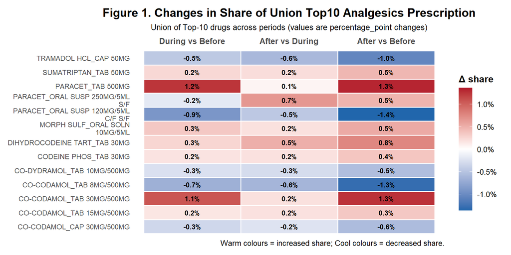

```r
## Track changes in share for the union of top-10 drugs and visualise as a heatmap
# Union of Top-10 analgesic codes across all periods
top10_union <- Top10_each_period_data %>%
  distinct(bnf_item_code, bnf_item_description)
# Pull paid_items for union codes from full period data, then compute share
union_shares <- AnalgesicsAllPeriods %>%
  semi_join(top10_union, by = "bnf_item_code") %>%
  left_join(Period_totals_data, by = "period") %>%
  mutate(share = paid_items / total_paid_items) %>%
  select(period, bnf_item_code, bnf_item_description, share) %>%
  pivot_wider(names_from  = period, values_from = share, values_fill = 0)
# Contrast the percentage share of the union top-10 drugs before vs during vs after COVID
union_change <- union_shares %>%
  mutate(`During vs Before` = `During COVID` - `Before COVID`,
         `After vs During`  = `After COVID`  - `During COVID`,
         `After vs Before`  = `After COVID`  - `Before COVID`) %>%
  pivot_longer(cols = c(`During vs Before`,`After vs During`,`After vs Before`), names_to = "contrast", values_to = "delta")
# Order rows by maximum absolute share change across contrasts to highlight drugs with the largest compositional shifts
order_levels <- union_change %>%
  group_by(bnf_item_description) %>%
  summarise(max_abs = max(abs(delta)), .groups="drop") %>%
  arrange(desc(max_abs)) %>%
  pull(bnf_item_description)
# Heatmap
union_change_plot <- union_change %>%
  mutate(contrast = factor(contrast, levels = c("During vs Before", "After vs During", "After vs Before")), bnf_item_description = factor(bnf_item_description, levels = rev(order_levels)), drug_label = str_wrap(bnf_item_description, width = 28))
# Symmetric colour limits around 0
lim <- max(abs(union_change_plot$delta), na.rm = TRUE)
ggplot(union_change_plot, aes(x = contrast, y = drug_label, fill = delta)) +
  geom_tile(color = "white", linewidth = 0.6) +
  geom_text(aes(label = percent(delta, accuracy = 0.1)), size = 3.2, fontface = "bold") +
  scale_fill_gradient2(low = "#2166ac", mid = "white", high = "#b2182b", limits = c(-lim, lim), breaks = pretty_breaks(5), labels = percent_format(accuracy = 0.1), name = "Δ share")+
  scale_x_discrete(position = "top") +
  labs(title = "Figure 1. Changes in Share of Union Top10 Analgesics Prescription", subtitle = "Union of Top-10 drugs across periods (values are percentage_point changes)", x = NULL, y = NULL, caption = "Warm colours = increased share; Cool colours = decreased share.") + theme_minimal(base_size = 12) + theme(panel.grid = element_blank(), axis.text.x = element_text(face = "bold", size = 10), axis.text.y = element_text(size = 9), plot.title = element_text(face = "bold", size = 15, hjust = 0.5), plot.subtitle = element_text(size = 10, hjust = 0.5, margin = margin(b=8)), legend.title = element_text(face = "bold"), legend.key.height = unit(1.1, "cm"), plot.margin = margin(10, 12, 10, 10))
```

## Figure 2. Monthly Presciptions of All Analgesics in Scotland

To assess whether changes in drug share reflected redistribution within a stable total volume or shifts in overall analgesic use, Figure 2 presents monthly totals for all BNF 04.07 items from before COVID to after COVID, with the COVID restriction period shaded.

The series shows a pronounced peak around March 2020 (i.e. start of COVID-19), followed by a temporary reduction during the restriction period and a steady recovery from 2022 onwards, reaching slightly higher levels than in the pre-pandemic years. The short-lived surge at the onset of COVID-19 may reflect anticipatory stockpiling. The mid-pandemic dip aligns with reduced primary-care contact and fewer non-COVID illnesses. The subsequent rebound and mild overshoot may reflect catch-up of deferred care and ongoing pain needs in patients whose treatment or procedures were delayed.

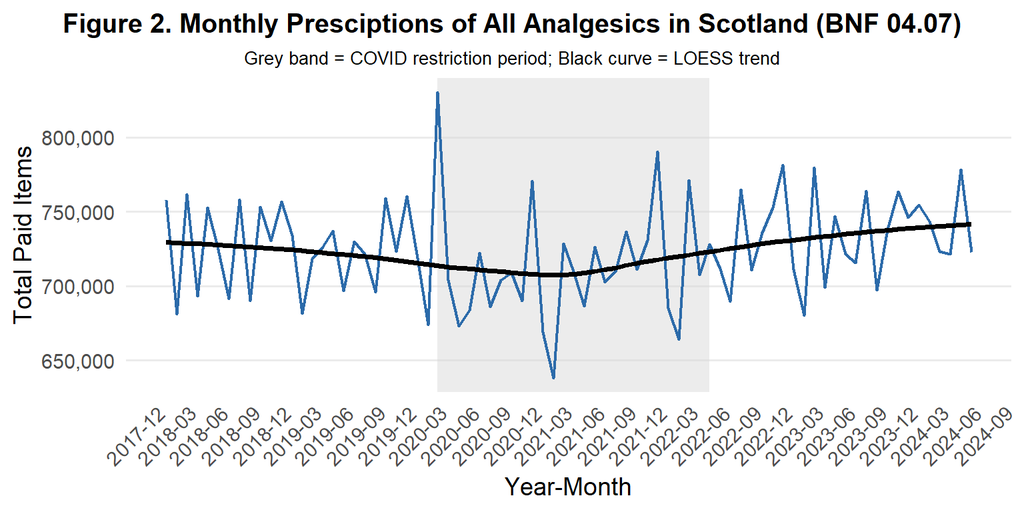

```r
## Purpose: Show overall monthly volume of all analgesics across the study period
# Monthly Analgesics Data
read_cols_month <- function(path, period_label){
  yyyymm <- str_extract(basename(path), "\\d{6}")
read_csv(path, show_col_types = FALSE) %>%
  clean_names() %>%
  select("bnf_item_code", "bnf_item_description", "number_of_paid_items") %>%
  mutate(covid_period = period_label, month  = yyyymm, bnf_item_description = str_squish(bnf_item_description)) %>%
  filter(startsWith(bnf_item_code, "0407"))}
load_monthly <- function(folder, period_label){
  files <- list.files(here("data", folder), pattern = "csv", full.names = TRUE)
  map_dfr(files, read_cols_month, period_label = period_label)}
AllMonthly <- bind_rows(load_monthly("before", "Before COVID"), load_monthly("during", "During COVID"), load_monthly("after",  "After COVID")) %>%
  mutate(covid_period = factor(covid_period, levels = c("Before COVID","During COVID","After COVID")), month = as.character(month)) %>%
  filter(!is.na(bnf_item_code), !is.na(bnf_item_description), !is.na(number_of_paid_items), !is.na(month))
# Confirm parsing issue unrelated
problems(AllMonthly) %>%
  filter(col %in% c("bnf_item_code","bnf_item_description","number_of_paid_items", "month"))
# Monthly totals for analgesics Figure
Analgesics_monthly_totals <- AllMonthly %>%
  group_by(month) %>%
  summarise(total_paid_items = sum(number_of_paid_items, na.rm = TRUE), .groups = "drop") %>% mutate(month_date = ym(month))
# Define periods on graph
covid_start <- ym("2020-03")
covid_end <- ym("2022-05")
covid_band <- tibble(xmin = covid_start, xmax = covid_end, ymin = -Inf, ymax = Inf)
# Plot Monthly Presciptions of All Analgesics in Scotland
ggplot(Analgesics_monthly_totals, aes(x = month_date, y = total_paid_items)) +
  geom_rect(data = covid_band, aes(xmin = xmin, xmax = xmax, ymin = ymin, ymax = ymax), inherit.aes = FALSE, fill = "grey85", alpha = 0.5) +
  geom_line(linewidth = 0.8, colour = "#2C6BAA") +
  geom_smooth(method = "loess", se = FALSE, colour = "black") +
  scale_x_date(date_breaks="3 months", date_labels="%Y-%m") +
  scale_y_continuous(labels=comma) +
  labs(title = "Figure 2. Monthly Presciptions of All Analgesics in Scotland (BNF 04.07)", subtitle = "Grey band = COVID restriction period; Black curve = LOESS trend", x = "Year-Month", y = "Total Paid Items") +
  theme_minimal(base_size = 14) +
  theme(panel.grid.major.x = element_blank(), panel.grid.minor = element_blank(), axis.text.x = element_text(angle = 45, hjust = 1), plot.title.position = "plot", plot.title = element_text(face = "bold", size = 15, hjust = 0.5), plot.subtitle = element_text(size = 10, margin = margin(b = 6), hjust = 0.5))
```

## Figure 3. Monthly Prescriptions of Union Top10 Analgesics

Building on the aggregate pattern in Figure 2, Figure 3 examines monthly trajectories for individual top-10 analgesics to identify which drugs contributed to the stable total volume and which diverged.

Taken together, these drug-specific trajectories indicate that the brief pandemic-related disturbance rapidly stabilised, and that longer-term changes reflect a gradual redistribution within the analgesic formulary rather than shifts in total demand.

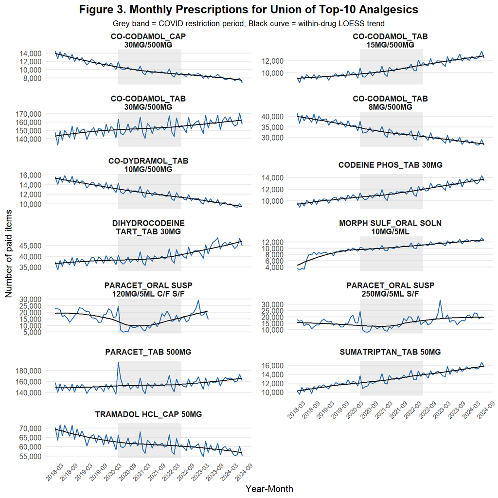

```r
## Purpose: Examine drug-specific trajectories for the union of top-10 analgesics
# Label Top10 analgesic codes across all periods
code_labels <- union_shares %>%
  distinct(bnf_item_code, bnf_item_description) %>%
  mutate(bnf_item_description = str_squish(bnf_item_description), label = bnf_item_description)
top10_union_codes <- code_labels %>%
  pull(bnf_item_code)
# Monthly totals for Union drugs only
top10_monthly_code <- AllMonthly %>%
 filter(bnf_item_code %in% top10_union_codes) %>%
  mutate(bnf_item_description = str_squish(bnf_item_description), month_date = ym(month)) %>%
  group_by(month_date, bnf_item_code) %>%
  summarise(paid_items = sum(number_of_paid_items, na.rm = TRUE), .groups = "drop") %>%
  left_join(code_labels, by = "bnf_item_code")
# Plot Monthly Prescriptions of Union Top10 Analgesics
ggplot(top10_monthly_code, aes(x = month_date, y = paid_items)) +
  geom_rect(data = covid_band, aes(xmin = xmin, xmax = xmax, ymin = ymin, ymax = ymax), inherit.aes = FALSE, fill = "grey85", alpha = 0.5) +
  geom_line(linewidth = 0.7, colour = "#2C6BAA") +
  geom_smooth(method = "loess", se = FALSE, linewidth = 0.6, colour = "black")+
  facet_wrap(~ label, scales = "free_y", ncol = 2, labeller = label_wrap_gen(width = 22)) +
  scale_x_date(date_breaks = "6 months", date_labels = "%Y-%m") +
  scale_y_continuous(labels = comma, breaks = scales::pretty_breaks(4)) +
  labs(title = "Figure 3. Monthly Prescriptions for Union of Top-10 Analgesics", subtitle = "Grey band = COVID restriction period; Black curve = within-drug LOESS trend", x = "Year-Month", y = "Number of paid items")+
  theme_minimal(base_size = 12) +
  theme(panel.grid.minor = element_blank(), panel.grid.major.x = element_blank(), strip.text = element_text(face = "bold", size = 10, margin = margin(b=2)), strip.background = element_rect(fill = NA, colour = NA), panel.spacing = unit(0.9, "lines"), axis.text.x = element_text(size = 8, angle = 45, hjust = 1), plot.title.position = "plot", plot.title = element_text(face = "bold", size = 15, hjust = 0.5), plot.subtitle = element_text(size = 10, margin = margin(b = 6), hjust = 0.5))
```

# Conclusion

Overall, Scottish community analgesic prescribing remained highly stable across the pre-, during-, and post-COVID periods, with no pandemic-driven surge in total volume. The main shifts were compositional: paracetamol 500mg and co-codamol 30/500mg tablets remained dominant with slight post-COVID increases; several opioid formulations declined; and selected agents such as sumatriptan, dihydrocodeine, codeine phosphate, morphine oral solution showed modest growth. Paediatric formulations displayed age-specific disruption and recovery. These findings indicate a largely steady formulary with subtle redistribution among drug classes rather than major COVID-induced changes in overall analgesic demand.

However, interpretation is limited by several factors. Paid-item counts measure dispensing events only and do not capture dose, treatment duration, indication, or over-the-counter and hospital supply. The analysis uses aggregate data and focuses on the union of the top-10 drugs, so it cannot identify patient-level variation by age, deprivation, or diagnosis, nor trends in less commonly prescribed agents. Broad period definitions may also obscure short-term policy phases or regional differences, and the descriptive design cannot establish causality.

Future work should incorporate dose-based metrics and link prescribing records to demographic and clinical datasets to explore subgroup differences and policy effects. Extending the time horizon and applying formal time-series methods would clarify the persistence and drivers of these trends, and the same workflow could be adapted to monitor other therapeutic areas.

# References

Beng, T.S., Kim, C.L.C., Shee, C.C., Ching, D.N.L., Liang, T.J., Kumar, M.K.N., Guan, N.C., Khuen, L.P., Loong, L.C., Chin, L.E. and Zainuddin, S.I., (2022) ‘COVID-19, Suffering and Palliative Care: A Review’, American Journal of Hospice and Palliative Medicine®, 39(8), pp. 986-995. Available at: https://doi.org/10.1177/10499091211046233.

Chauhan, R (2020) ‘Managing COVID-19 symptoms (including at the end of life) in the community: summary of NICE guidelines’ (2020) BMJ, p. m1461. Available at: https://doi.org/10.1136/bmj.m1461.

Evcik, D. (2023) ‘Musculoskeletal involvement: COVID-19 and post COVID 19’, Turkish Journal of Physical Medicine and Rehabilitation, 1(1), pp. 1–7. Available at: https://doi.org/10.5606/tftrd.2023.12521.

Levy, N., Lord, L.J. and Lobo, D.N. (2021). ‘UK recommendations on opioid stewardship’, BMJ, 372, pp.m4901. Available at: https://doi.org/10.1136/bmj.m4901.

Nalbandian, A., Sehgal, K., Gupta, A., Madhavan, M.V., McGroder, C., Stevens, J.S., Cook, J.R., Nordvig, A.S., Shalev, D., Sehrawat, T.S. and Ahluwalia, N. (2021) ‘Post-acute COVID-19 syndrome’, Nature Medicine, 27(4), pp. 1–15. Available at: https://doi.org/10.1038/s41591-021-01283-z.

NHS (2022a) About tramadol. Available at: https://www.nhs.uk/medicines/tramadol/about-tramadol/#:~:text=Tramadol%20is%20a%20strong%20painkiller,usually%20only%20done%20in%20hospital. (Accessed: 26 November 2025).

NHS (2022b) About sumatriptan. Available at: https://www.nhs.uk/medicines/sumatriptan/about-sumatriptan/ (Accessed: 26 November 2025).

NHS (2024) A patient’s guide to Oramorph (morphine sulphate oral solution10mg/5ml) for use in breathlessness. Available at: https://www.buckshealthcare.nhs.uk/pifs/a-patients-guide-to-oramorph-morphine-sulphate-oral-solution-10mg-5ml-for-use-in-breathlessness/#:~:text=What%20is%20Oramorph?,with%20continued%20use%20of%20Oramorph. (Accessed: 26 November 2025).

NHS (2023) How and when to take co-codamol for adults. Available at: https://www.nhs.uk/medicines/co-codamol-for-adults/how-and-when-to-take-co-codamol-for-adults/ (Accessed: 26 November 2025).

NHS (2025) Paracetamol for children (Calpol). Available at: https://www.nhs.uk/medicines/paracetamol-for-children/ (Accessed: 26 November 2025).

NICE (2025) Codeine phosphate. Available at: https://bnf.nice.org.uk/drugs/codeine-phosphate/#:~:text=Oral%20tablet,given%20for%20the%20shortest%20duration. (Accessed: 26 November 2025).

Open Prescribing (2025) All BNF sections. Available at: https://openprescribing.net/bnf/ (Accessed: 26 November 2025).

Public Health Scotland (2025) Prescriptions in the Community. Available at: https://www.opendata.nhs.scot/dataset/prescriptions-in-the-community (Accessed: 26 November 2025).

Scottish COVID-19 Inquiry (2025) COVID-19 Pandemic in Scotland - a timeline of key dates. Available at: https://www.covid19inquiry.scot/covid-19-pandemic-scotland-timeline-key-dates (Accessed: 26 November 2025).

UKMI (2014) Tramadol: new legal classification. Available at: https://www.derbyshiremedicinesmanagement.nhs.uk/assets/Controlled_Drugs/Tramadol_new_legal_classification_June_2014.pdf (Accessed: 26 November 2025).